# BTL_XSTL_KHOA MAY TINH

Vo_Pham

2024-11-02

# I. TIỀN XỬ LÝ SỐ LIỆU

1. Lựa chọn tính năng:

Bài tập này tập trung vào phân tích tốc độ bộ nhớ của GPU. Tốc độ xung nhịp bộ nhớ có tác động đáng kể đến hiệu suất của GPU, đặc biệt trong các tác vụ đòi hỏi truy cập dữ liệu lớn. Xung nhịp bộ nhớ cao hơn cho phép GPU truy cập bộ nhớ nhanh hơn, từ đó nâng cao hiệu suất tổng thể. Một số tính năng quan trọng đã được lựa chọn để đánh giá tốc độ bộ nhớ,bao gồm: “Memory_Bandwidth”,“Memory” ,“Memory_Speed”, “L2_Cache”, “Memory_Bus”, “Dedicated”,“Shader”, “Manufacturer”.

2. Đọc dữ liệu:

Bắt đầu bằng cách xem qua toàn bộ thông tin trong tập dữ liệu để nắm bắt tổng quan. Sau đó, hiển thị bản xem trước của một vài dòng đầu tiên để có cái nhìn sơ bộ về cấu trúc và cách trình bày dữ liệu. Bước này giúp làm quen với tập dữ liệu và hiểu rõ cấu trúc trước khi đi sâu vào phân tích chi tiết.  
Đọc tệp tin All_GPUs, in kết quả 10 dòng đầu tiên của dữ liệu như hình 1:

```r
# Đọc dữ liệu từ file CSV có tên "All_GPUs.csv"
All_GPUs <- read.csv("~/archive/All_GPUs.csv")
# Hiển thị 10 dòng đầu tiên của dữ liệu đã đọc
head(All_GPUs, 10)
```

```
##       Architecture Best_Resolution Boost_Clock Core_Speed DVI_Connection
## 1      Tesla G92b                                 738 MHz              2
## 2         R600 XT       1366 x 768                   \n-               2
## 3        R600 PRO       1366 x 768                   \n-               2
## 4           RV630       1024 x 768                   \n-               2
## 5           RV630       1024 x 768                   \n-               2
## 6           RV630       1024 x 768                   \n-               2
## 7   R700 RV790 XT      1920 x 1080                870 MHz              1
## 8         R600 GT       1024 x 768                   \n-               2
## 9  Pitcairn XT GL      1920 x 1080                   \n-               0
## 10          RV100                                    \n-              NA
##    Dedicated Direct_X DisplayPort_Connection HDMI_Connection Integrated
## 1        Yes  DX 10.0                     NA               0         No
## 2        Yes    DX 10                     NA               0         No
## 3        Yes    DX 10                     NA               0         No
```

[output cut: 62 more lines]

3. Kiểm tra dữ liệu khuyết trong tập tin.

Tìm các hàng trống (tức là các hàng mà toàn bộ giá trị là rỗng hoặc ” “) trong dữ liệu và chuyển đổi chúng thành giá trị NA.

```r
# Thay thế tất cả các ô trống trong dữ liệu GPU_data bằng NA
All_GPUs[All_GPUs == ""] <- NA
```

Tìm các giá trị trong dataframe có định dạng là dấu gạch ngang (các giá trị bắt đầu bằng ký tự xuống dòng và theo sau là dấu `-`) và thay thế chúng bằng giá trị NA. Sử dụng lệnh `gsub()` để thay thế tất cả các dấu `-` trong dataframe thành NA để đảm bảo việc xử lý dữ liệu được nhất quán.

```r
# Thay thế các giá trị có định dạng "\n-" bằng NA trong tất cả các cột của GPU_data
All_GPUs[] <- lapply(All_GPUs, function(x) gsub("^\\n- $", NA, x))

# Thay thế các chuỗi "NA" bằng NA
All_GPUs[All_GPUs == "NA"] <- NA
```

Nếu hàm `gsub()` không thể trực tiếp chuyển các giá trị thành NA vì NA không phải là một chuỗi ký tự, thì có thể thay thế các giá trị này thành chuỗi `"NA"` trước. Sau đó, nếu cần, chuyển đổi các chuỗi `"NA"` trong dataframe thành giá trị NA thực sự để đảm bảo dữ liệu được chuẩn hóa đúng cách. Kết quả được hiển thị trong hình 2.

```r
# Hiển thị 6 dòng đầu tiên của dữ liệu đã được kiểm tra và thay thế bằng NA
head(All_GPUs)
```

```
##   Architecture Best_Resolution Boost_Clock Core_Speed DVI_Connection Dedicated
## 1  Tesla G92b             <NA>        <NA>    738 MHz              2       Yes
## 2     R600 XT       1366 x 768        <NA>       <NA>              2       Yes
## 3    R600 PRO       1366 x 768        <NA>       <NA>              2       Yes
## 4       RV630       1024 x 768        <NA>       <NA>              2       Yes
## 5       RV630       1024 x 768        <NA>       <NA>              2       Yes
## 6       RV630       1024 x 768        <NA>       <NA>              2       Yes
##   Direct_X DisplayPort_Connection HDMI_Connection Integrated L2_Cache
## 1  DX 10.0                   <NA>               0         No      0KB
## 2    DX 10                   <NA>               0         No      0KB
## 3    DX 10                   <NA>               0         No      0KB
## 4    DX 10                   <NA>               0         No      0KB
## 5    DX 10                   <NA>               0         No      0KB
## 6    DX 10                   <NA>               0         No      0KB
##   Manufacturer Max_Power   Memory Memory_Bandwidth Memory_Bus Memory_Speed
```

[output cut: 34 more lines]

Tiếp theo ta thực hiện thống kê số lượng và tỷ lệ dữ liệu khuyết ở các biến:

```r
# Tạo bảng thống kê số lượng và tỷ lệ dữ liệu khuyết
find_NA <- data.frame(
  Column = names(All_GPUs),
  SoLuong_NA = sapply(All_GPUs, function(x) sum(is.na(x))),
  NA_Percentage = sapply(All_GPUs, function(x) mean(is.na(x)) * 100)
)
# Hiển thị bảng thống kê

 #Gọi thư viện questionr để có thể sử dụng hàm freqq.na
library(questionr)
#Thống kê số lượng và tỷ lệ dữ liệu khuyết bằng hàm freq.na
freq.na(All_GPUs)
```

```
##                        missing  %
## Release_Price             2850 84
## DisplayPort_Connection    2549 75
## Boost_Clock               1960 58
## PSU                       1175 34
## Core_Speed                 907 27
## HDMI_Connection            763 22
## VGA_Connection             758 22
## DVI_Connection             750 22
## Power_Connector            709 21
## Best_Resolution            642 19
## Max_Power                  625 18
## Pixel_Rate                 544 16
## Texture_Rate               544 16
## ROPs                       538 16
## TMUs                       538 16
## Process                    463 14
## Memory                     420 12
## Resolution_WxH             195  6
## Memory_Bandwidth           121  4
## Shader                     107  3
## Memory_Speed               105  3
## Architecture                62  2
## Memory_Bus                  62  2
## Memory_Type                 56  2
## Open_GL                     40  1
## Dedicated                   14  0
## Integrated                  14  0
## Direct_X                     6  0
## L2_Cache                     0  0
## Manufacturer                 0  0
## Name                         0  0
## Notebook_GPU                 0  0
## Release_Date                 0  0
## SLI_Crossfire                0  0
```

Dựa trên kết quả thu được, có thể nhận thấy rằng khá nhiều biến chứa dữ liệu khuyết. Vì vậy, để trực quan hóa tỷ lệ này, ta cần sử dụng hàm từ thư viện `ggplot2` để vẽ biểu đồ thể hiện tỷ lệ dữ liệu khuyết cho từng biến. Việc này giúp dễ dàng nhận diện và đánh giá mức độ khuyết của dữ liệu trong từng cột, hỗ trợ các quyết định xử lý dữ liệu hiệu quả hơn.

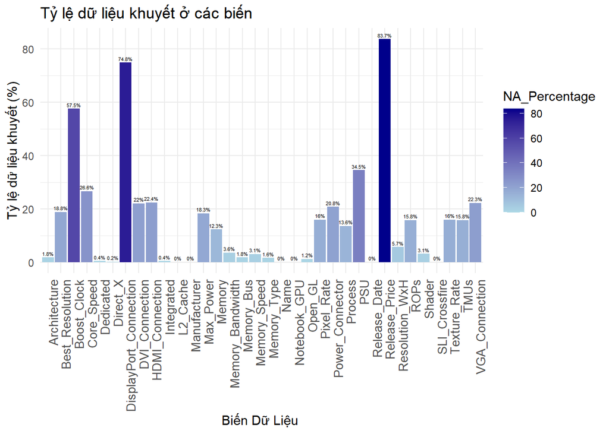

```r
# Gọi thư viện ggplot2 để sử dụng hàm ggplot
library(ggplot2)
# Tạo biểu đồ cột cho tỷ lệ dữ liệu khuyết ở các biến
ggplot(find_NA, aes(x = Column, y = NA_Percentage, fill = NA_Percentage)) +
  geom_bar(stat = "identity") +
   scale_fill_gradient(low = "lightblue", high = "darkblue", ) + # Đổi màu gradient
  geom_text(aes(label = paste0(round(NA_Percentage, 1), "%")),
            vjust = -0.5, size = 1.5 ) +
  labs(title = "Tỷ lệ dữ liệu khuyết ở các biến",
       x = "Biến Dữ Liệu ",
       y = "Tỷ lệ dữ liệu khuyết (%)") +
  theme_minimal() +
  theme(axis.text.x = element_text(size = 10, angle = 90, hjust = 1))
```

```r
# Lọc các cột có tỷ lệ dữ liệu khuyết dưới 15%
selected_columns <- find_NA$Column[find_NA$NA_Percentage < 15 ]

# Giữ lại các cột thỏa mãn điều kiện trong dataframe ban đầu
new_GPU_data <- All_GPUs[, selected_columns]
```

Quy trình làm sạch dữ liệu sẽ giữ lại các giá trị NA trừ khi việc loại bỏ chúng là thực sự cần thiết. Trong một số trường hợp, các giá trị NA có thể chứa thông tin quan trọng mà không nên xóa bỏ tùy tiện; vì vậy, chúng không luôn được xem là dữ liệu không hợp lệ. Dựa vào bối cảnh nghiên cứu, khi chúng ta tập trung vào các mẫu dữ liệu cụ thể, chiến lược xử lý giá trị NA sẽ được điều chỉnh linh hoạt để đảm bảo không bỏ sót bất kỳ thông tin nào có giá trị.

```r
#Xoá các quan sát chứa dữ liệu khuyết
new_GPU_data<-na.omit(new_GPU_data)

# Hiển thị 10 dòng đầu tiên của dữ liệu sau khi đã những biến có tỷ lệ khuyết cao
head(new_GPU_data, 10)
```

```
##       Architecture Dedicated Direct_X Integrated L2_Cache Manufacturer   Memory
## 1      Tesla G92b        Yes  DX 10.0         No      0KB       Nvidia 1024 MB
## 2         R600 XT        Yes    DX 10         No      0KB          AMD  512 MB
## 3        R600 PRO        Yes    DX 10         No      0KB          AMD  512 MB
## 4           RV630        Yes    DX 10         No      0KB          AMD  256 MB
## 5           RV630        Yes    DX 10         No      0KB          AMD  256 MB
## 6           RV630        Yes    DX 10         No      0KB          AMD  256 MB
## 7   R700 RV790 XT        Yes  DX 10.1         No      0KB          AMD 2048 MB
## 8         R600 GT        Yes    DX 10         No      0KB          AMD  256 MB
## 9  Pitcairn XT GL        Yes  DX 11.2         No      0KB          AMD 2048 MB
## 12    Fermi GF110        Yes  DX 12.0         No    768KB       Nvidia 6144 MB
##    Memory_Bandwidth Memory_Bus Memory_Speed Memory_Type
## 1          64GB/sec   256 Bit      1000 MHz       GDDR3
## 2         106GB/sec   512 Bit       828 MHz       GDDR3
## 3        51.2GB/sec   256 Bit       800 MHz       GDDR3
```

[output cut: 29 more lines]

4. Làm sạch các biến và xử lý định dạng các biến:

Nhận thấy rằng tất cả dữ liệu trong một tính năng đều sử dụng cùng một đơn vị đo. Để thuận lợi hơn cho việc quan sát và phân tích, chúng tôi đã quyết định loại bỏ tất cả các đơn vị khỏi các tính năng như “L2_Cache”,“Memory_Bandwidth”,“Memory_Bus”,“Memory_Speed”,“Memory” và “Process”. Việc này không chỉ giúp tăng tính đồng nhất trong phân tích mà còn đơn giản hóa việc so sánh và diễn giải dữ liệu trên các tính năng này.

```r
# Lựa chọn các biến cần xoá đơn vị
  columns_to_clean <- c("L2_Cache","Memory_Bandwidth","Memory_Bus","Memory_Speed", "Memory", "Process" )

#Tạo hàm thực hiện xoá đơn vị ở các biến
  remove_units <- function(column) {
# Sử dụng gsub để xóa tất cả các ký tự không phải số (kể cả đơn vị)
  cleaned_column <- gsub("[^0-9.]", "", column)
# Chuyển đổi kết quả về kiểu numeric
  cleaned_column <- as.numeric(cleaned_column)

  return(cleaned_column)
  }

# Áp dụng hàm cho các biến đã chọn
new_GPU_data[columns_to_clean] <- lapply(new_GPU_data[columns_to_clean], remove_units)
```

```r
head(new_GPU_data, 10)
```

```
##       Architecture Dedicated Direct_X Integrated L2_Cache Manufacturer Memory
## 1      Tesla G92b        Yes  DX 10.0         No        0       Nvidia   1024
## 2         R600 XT        Yes    DX 10         No        0          AMD    512
## 3        R600 PRO        Yes    DX 10         No        0          AMD    512
## 4           RV630        Yes    DX 10         No        0          AMD    256
## 5           RV630        Yes    DX 10         No        0          AMD    256
## 6           RV630        Yes    DX 10         No        0          AMD    256
## 7   R700 RV790 XT        Yes  DX 10.1         No        0          AMD   2048
## 8         R600 GT        Yes    DX 10         No        0          AMD    256
## 9  Pitcairn XT GL        Yes  DX 11.2         No        0          AMD   2048
## 12    Fermi GF110        Yes  DX 12.0         No      768       Nvidia   6144
##    Memory_Bandwidth Memory_Bus Memory_Speed Memory_Type
## 1              64.0        256         1000       GDDR3
## 2             106.0        512          828       GDDR3
## 3              51.2        256          800       GDDR3
```

[output cut: 29 more lines]

Để đảm bảo rằng quá trình làm sạch dữ liệu đã hoàn tất, chúng tôi tiến hành kiểm tra số lượng giá trị bị thiếu. Kết quả cho thấy, không có dữ liệu nào bị khuyết trong tập dữ liệu cuối cùng Hình 3. Điều này khẳng định quá trình làm sạch đã thành công, giúp chúng tôi sở hữu một bộ dữ liệu hoàn chỉnh và sẵn sàng cho các bước phân tích tiếp theo.

```r
apply(is.na(new_GPU_data), 2, sum)
```

```
##     Architecture        Dedicated         Direct_X       Integrated
##                0                0                0                0
##         L2_Cache     Manufacturer           Memory Memory_Bandwidth
##                0                0                0                0
##       Memory_Bus     Memory_Speed      Memory_Type             Name
##                0                0                0                0
##     Notebook_GPU          Open_GL          Process     Release_Date
##                0                0                0                0
##   Resolution_WxH    SLI_Crossfire           Shader
##                0                0                0
```

```r
dim(new_GPU_data)
```

```
## [1] 2637   19
```

Sau khi tiến hành làm sạch bộ dữ liệu, chúng ta đã thu được 19 biến cùng với 2637 quan sát có giá trị. Giai đoạn tiếp theo của là xác định và lựa chọn các biến quan trọng, trong đó Memory_Bandwidth nổi bật như một yếu tố thiết yếu trong việc đánh giá hiệu suất của các GPU.

Tuy nhiên, các biến Architecture, Direct_X, và Resolution_WxH là những biến dạng chuỗi có nhiều giá trị khác nhau, làm tăng độ phức tạp cho mô hình hồi quy. Do đó, để tối ưu hóa phân tích, chúng ta sẽ giữ lại các biến độc lập như Memory, Memory_Speed, L2_Cache, Memory_Bus, Shader và Dedicated. Ngoài ra, biến Manufacturer cũng sẽ được đưa vào phân tích, nhằm so sánh hiệu suất Memory_Bandwidth giữa các GPU đến từ các nhà sản xuất khác nhau.

Để hiểu rõ hơn về tác động của các yếu tố này đối với Memory_Bandwidth trong GPU, bạn có thể tham khảo một số tài liệu hữu ích sau:  
- https://www.digitalocean.com/community/tutorials/gpu-memory-bandwidth  
- https://blog.paperspace.com/understanding-memory-bandwidth-benchmarks/

5. Tạo bộ dữ liệu bao gồm các biến chính để phân tích:

Như vậy, chúng ta đã hoàn tất quá trình làm sạch dữ liệu và hiện có trong tay một bộ dữ liệu đầy đủ, sẵn sàng cho các bước phân tích tiếp theo.

```r
main_GPU_data<-new_GPU_data[c("Memory_Bandwidth", "Memory", "Memory_Speed","L2_Cache","Memory_Bus","Dedicated",  "Shader","Manufacturer")]
head(main_GPU_data, 10)
```

```
##    Memory_Bandwidth Memory Memory_Speed L2_Cache Memory_Bus Dedicated Shader
## 1              64.0   1024         1000        0        256       Yes      4
## 2             106.0    512          828        0        512       Yes      4
## 3              51.2    512          800        0        256       Yes      4
## 4              36.8    256         1150        0        128       Yes      4
## 5              22.4    256          700        0        128       Yes      4
## 6              35.2    256         1100        0        128       Yes      4
## 7             134.4   2048         1050        0        256       Yes    4.1
## 8              51.2    256          800        0        256       Yes      4
## 9             160.0   2048         1250        0        256       Yes      5
## 12            177.6   6144          925      768        384       Yes      5
##    Manufacturer
## 1        Nvidia
## 2           AMD
## 3           AMD
## 4           AMD
## 5           AMD
## 6           AMD
## 7           AMD
## 8           AMD
## 9           AMD
## 12       Nvidia
```

# II. THỐNG KÊ MÔ TẢ

1. Phân tích dữ liệu:

Trước khi tiến hành phân tích dữ liệu, cần phân biệt rõ giữa biến định lượng và biến phân loại. Biến định lượng là những biến có giá trị số học, cho phép thực hiện các phép toán và phân tích thống kê, bao gồm cả biến liên tục (như chiều cao, nhiệt độ) và biến rời rạc (như số lượng sản phẩm). Trong khi đó, biến phân loại dùng để biểu thị các nhóm hoặc đặc điểm, chẳng hạn như giới tính, màu sắc, hoặc loại sản phẩm. Các biến này thường được biểu diễn bằng nhãn và không phù hợp cho các phép tính số học. Việc phân loại chính xác các biến này giúp lựa chọn phương pháp phân tích phù hợp, từ đó nâng cao độ chính xác và giá trị của kết quả phân tích.

Đối với các biến định lượng, bao gồm cả biến liên tục và rời rạc, chúng ta tiến hành tính các thống kê mô tả như trung bình, độ lệch chuẩn mẫu, các phân vị, trung vị, giá trị lớn nhất và giá trị nhỏ nhất. Những thống kê này giúp chúng ta có cái nhìn toàn diện hơn về sự phân bố và đặc điểm của dữ liệu.

```r
# Xác định các biến số và tạo một khung dữ liệu chỉ chứa các biến số
new_numeric_vars <- sapply(main_GPU_data, is.numeric)
numeric_data <- main_GPU_data[, new_numeric_vars]

# Tính toán các thống kê mô tả cho các biến số
summary_stats <- sapply(numeric_data, function(x) {
  c(
    Mean = mean(x),                   # Trung bình
    SD = sd(x),                       # Độ lệch chuẩn
    Min = min(x),                     # Giá trị nhỏ nhất
    Q1 = quantile(x, 0.25),           # Phân vị 25%
    Median = median(x),               # Trung vị
    Q3 = quantile(x, 0.75),           # Phân vị 75%
    Max = max(x)                      # Giá trị lớn nhất
  )
})

# Chuyển thống kê mô tả thành dataframe và xuất ra dưới dạng bảng
t(as.data.frame(summary_stats))
```

```
##                       Mean        SD Min Q1.25% Median Q3.75%   Max
## Memory_Bandwidth  162.3657  136.5272   4     64  130.6  224.4  1280
## Memory           3140.9511 2829.5297 128   1024 2048.0 4096.0 32000
## Memory_Speed     1280.0959  396.8329 275    950 1251.0 1553.0  2127
## L2_Cache         1482.6280 3408.4255   0    256  512.0 1024.0 30722
## Memory_Bus        221.5821  234.9905  32    128  192.0  256.0  4096
```

```r
# Chuyển đổi Biến 'Dedicated' sang dạng factor
main_GPU_data$Dedicated <- as.factor(main_GPU_data$Dedicated)

# Chuyển đổi biến 'Shader' sang dạng factor
main_GPU_data$Shader <- as.factor(main_GPU_data$Shader)

# Chuyển đổi biến 'Manufacturer' sang dạng factor
main_GPU_data$Manufacturer <-as.factor(main_GPU_data$Manufacturer)
```

```r
# Thống kê số lượng biến Dedicated
summary(main_GPU_data$Dedicated)
```

```
##   No  Yes
##    3 2634
```

```r
# Thống kê số lượng biến Shader
summary(main_GPU_data$Shader)
```

```
##    2    3    4  4.1    5
##    9   10  149   86 2383
```

```r
# Thống kê số lượng biến Manufacturer
summary(main_GPU_data$Manufacturer)
```

```
##    AMD    ATI  Intel Nvidia
##   1004     82      3   1548
```

Dưới đây là bảng thống kê mô tả của tập dữ liệu `main_GPU_data`, giúp chúng ta nắm bắt các thông tin cơ bản về các biến định lượng và phân loại, từ đó hiểu rõ hơn về cấu trúc và đặc điểm của dữ liệu.

```r
summary(main_GPU_data)
```

```
##  Memory_Bandwidth     Memory       Memory_Speed     L2_Cache
##  Min.   :   4.0   Min.   :  128   Min.   : 275   Min.   :    0
##  1st Qu.:  64.0   1st Qu.: 1024   1st Qu.: 950   1st Qu.:  256
##  Median : 130.6   Median : 2048   Median :1251   Median :  512
##  Mean   : 162.4   Mean   : 3141   Mean   :1280   Mean   : 1483
##  3rd Qu.: 224.4   3rd Qu.: 4096   3rd Qu.:1553   3rd Qu.: 1024
##  Max.   :1280.0   Max.   :32000   Max.   :2127   Max.   :30722
##    Memory_Bus     Dedicated  Shader     Manufacturer
##  Min.   :  32.0   No :   3   2  :   9   AMD   :1004
##  1st Qu.: 128.0   Yes:2634   3  :  10   ATI   :  82
##  Median : 192.0              4  : 149   Intel :   3
##  Mean   : 221.6              4.1:  86   Nvidia:1548
##  3rd Qu.: 256.0              5  :2383
##  Max.   :4096.0
```

2. Vẽ đồ thị chỉ Tần Suất (Histogram) cho biến Memory_Bandwidth bằng đồ thị ggplot:

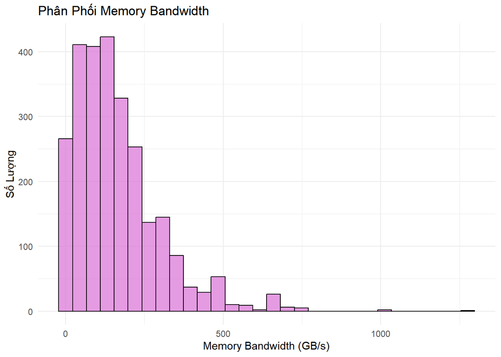

```r
  # Vẽ histogram cho biến Memory_Bandwidth
ggplot(main_GPU_data, aes(x = Memory_Bandwidth)) +
  geom_histogram(fill = "orchid", color = "black",alpha = 0.7) +  # Thay đổi binwidth theo yêu cầu
  labs(title = "Phân Phối Memory Bandwidth",
       x = "Memory Bandwidth (GB/s)",  # Ghi chú đơn vị nếu cần
       y = "Số Lượng") +
  theme_minimal()
```

Từ những đặc điểm trên, có thể khẳng định rằng Y không tuân theo phân phối chuẩn. Một phân phối chuẩn thông thường có hình dạng đối xứng, với phần lớn dữ liệu tập trung quanh giá trị trung bình và giảm đều về hai phía. Trong trường hợp này, sự tập trung dữ liệu ở băng thông thấp cùng với đuôi dài về bên phải đã tạo nên độ lệch đáng kể, điều này có thể ảnh hưởng đến các phân tích đòi hỏi tính chuẩn của dữ liệu, chẳng hạn như hồi quy tuyến tính thông thường.

- Chuẩn Hóa Cho Biến Memory Bandwidth (Y) và các biến ảnh hướng đến Y như “Memory_Speed”,“L2_Cache”,“Memory_Bus”,“Memory”:

Để chuẩn hóa dữ liệu trong trường hợp này, chúng ta sẽ áp dụng phép biến đổi logarit cho biến Memory Bandwidth (Y) và các biến “Memory_Speed”,“L2_Cache”,“Memory_Bus”,“Memory” . Việc này nhằm làm giảm ảnh hưởng của các giá trị cực lớn và giúp phân phối trở nên gần với phân phối chuẩn hơn, từ đó cải thiện hiệu quả của các mô hình phân tích dựa trên giả định tính chuẩn (như hồi quy tuyến tính).

Phép chuẩn hóa logarit cho biến 𝑌có thể được biểu diễn như sau:

```
     ln(Y) = b0 + b1*ln(X1) + b2*ln(X2) + ⋯ + ϵ
```

Trong đó:  
- ln(𝑌): là giá trị chuẩn hóa của Y bằng phép biến đổi logarit tự nhiên.  
- 𝑏0,𝑏1,𝑏2,…: là các tham số hồi quy cần ước lượng.  
- 𝑋1,𝑋2,…: là các biến độc lập (các yếu tố ảnh hưởng đến 𝑌).  
- ϵ: là sai số ngẫu nhiên trong mô hình.

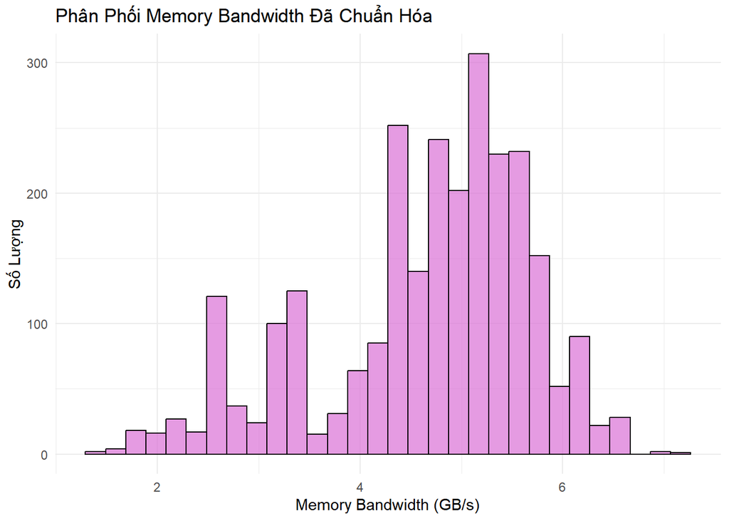

```r
# Chuân hóa Biến Memory_Bandwidth(Y) và các biến ảnh hướng đến Y như “Memory_Speed”,“L2_Cache”,“Memory_Bus”,“Memory”:
main_GPU_data$Memory_Bandwidth <- log(main_GPU_data$Memory_Bandwidth)
main_GPU_data$Memory_Speed <- log(main_GPU_data$Memory_Speed + 1 )
main_GPU_data$L2_Cache <- log(main_GPU_data$L2_Cache + 1 )
main_GPU_data$Memory_Bus <- log(main_GPU_data$Memory_Bus + 1 )
main_GPU_data$Memory <- log(main_GPU_data$Memory +1 )


# Vẽ histogram cho biến Memory_Bandwidth sau khi đã Chuẩn hóa
ggplot(main_GPU_data, aes(x = Memory_Bandwidth)) +
  geom_histogram(fill = "orchid", color = "black",alpha = 0.7) +  # Thay đổi binwidth theo yêu cầu
  labs(title = "Phân Phối Memory Bandwidth Đã Chuẩn Hóa ",
       x = "Memory Bandwidth (GB/s)",  # Ghi chú đơn vị nếu cần
       y = "Số Lượng") +
  theme_minimal()
```

3. Vẽ đồ thị Phân Tán (Scatter plot) cho biến Memory_Bandwidth theo các biến Định Lượng:
1. Scatter plot cho biến Memory_Bandwidth theo biến Memory_Speed:

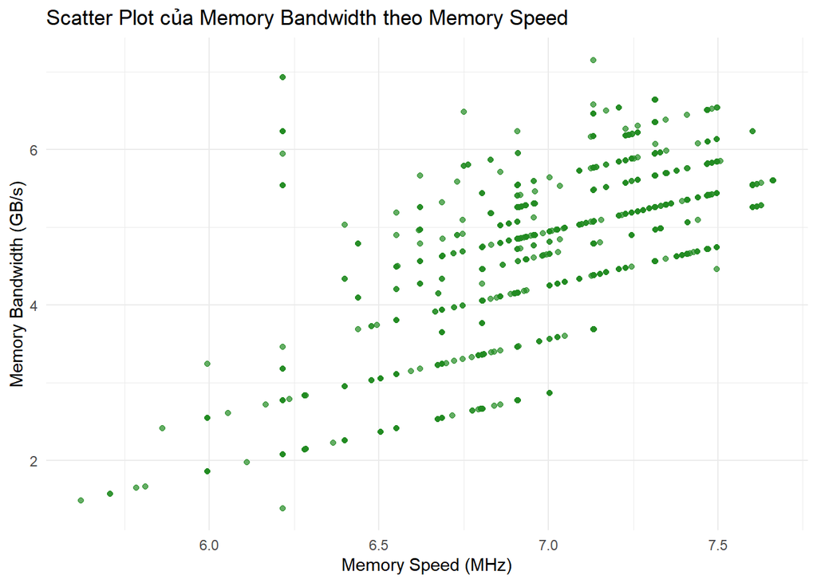

```r
  # Vẽ scatter plot cho Memory_Bandwidth theo Memory_Speed
ggplot(main_GPU_data, aes(x = Memory_Speed, y = Memory_Bandwidth)) +
  geom_point(color = "forestgreen", alpha = 0.7) +  # Thay đổi màu sắc và độ trong suốt của điểm
  labs(title = "Scatter Plot của Memory Bandwidth theo Memory Speed",
       x = "Memory Speed (MHz)",
       y = "Memory Bandwidth (GB/s)") +
  theme_minimal()
```

Sau khi chuẩn hóa biến Y (Memory Bandwidth), biểu đồ phân tán cho thấy mối quan hệ tuyến tính dương giữa Memory Speed (MHz) và Memory Bandwidth (GB/s). Cụ thể, khi tốc độ bộ nhớ tăng, băng thông bộ nhớ cũng có xu hướng tăng, ngụ ý rằng tốc độ bộ nhớ cao thường đi kèm với băng thông lớn hơn. Tuy nhiên, các điểm dữ liệu không hoàn toàn nằm trên một đường thẳng mà có sự phân tán nhất định, cho thấy có thể tồn tại các yếu tố khác ngoài Memory Speed ảnh hưởng đến Memory Bandwidth. Dù vậy, độ dốc của mối quan hệ này tương đối ổn định, cho thấy rằng Memory Speed và Memory Bandwidth có mối quan hệ khá nhất quán. Để đánh giá chính xác hơn về mức độ tương quan, cần áp dụng thêm các phương pháp phân tích thống kê.

Việc chuẩn hóa Memory Bandwidth giúp dữ liệu trở nên nhất quán và dễ so sánh hơn, đặc biệt là trong trường hợp có sự phân tán và ngoại lệ. Nhờ đó, biểu đồ sau chuẩn hóa sẽ làm nổi bật xu hướng chính mà không bị ảnh hưởng bởi các giá trị cực đoan, giúp ta thấy rõ hơn mối quan hệ tuyến tính giữa Memory Speed và Memory Bandwidth, từ đó hỗ trợ cho việc đánh giá và phân tích chính xác hơn.

2. Scatter plot cho biến Memory_Bandwidth theo biến L2_Cache:

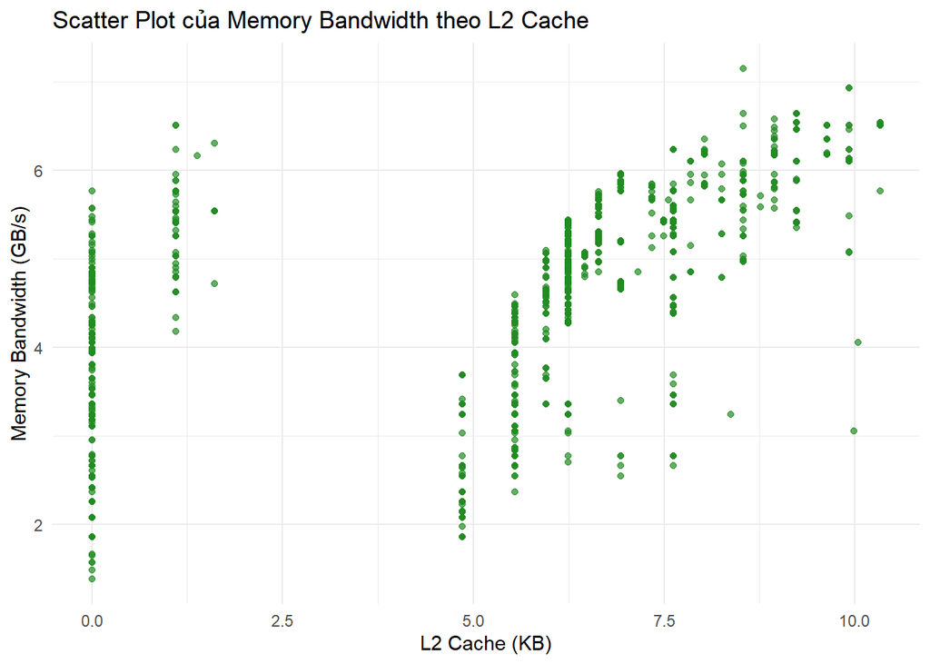

```r
# Vẽ scatter plot cho Memory_Bandwidth theo L2_Cache
ggplot(main_GPU_data, aes(x = L2_Cache, y = Memory_Bandwidth)) +
  geom_point(color = "forestgreen", alpha = 0.7) +  # Thay đổi màu sắc và độ trong suốt của điểm
  labs(title = "Scatter Plot của Memory Bandwidth theo L2 Cache",
       x = "L2 Cache (KB)",
       y = "Memory Bandwidth (GB/s)") +
  theme_minimal()
```

Biểu đồ cho thấy xu hướng Memory Bandwidth tăng dần khi kích thước L2 Cache tăng, phản ánh mối quan hệ tuyến tính dương giữa hai biến này. Điều này cho thấy rằng, khi dung lượng L2 Cache lớn hơn, hệ thống có xu hướng đạt được băng thông bộ nhớ cao hơn. Tuy nhiên, dữ liệu khá phân tán quanh xu hướng này, cho thấy không phải lúc nào L2 Cache lớn hơn cũng dẫn đến Memory Bandwidth cao hơn. Một số điểm ngoại lệ xuất hiện ở mức L2 Cache gần 0 KB nhưng vẫn có Memory Bandwidth rất cao, có thể do yếu tố kiến trúc hệ thống hoặc thiết kế phần cứng khác biệt. Phần lớn các điểm dữ liệu tập trung ở phạm vi Memory Bandwidth từ 4 đến 6 GB/s, đặc biệt khi L2 Cache đạt từ 5 KB trở lên, cho thấy mức độ ổn định hơn của băng thông bộ nhớ ở các giá trị L2 Cache cao.

Việc chuẩn hóa biến Memory Bandwidth (biến Y) sẽ mang lại lợi thế trong việc phân tích, đặc biệt khi dữ liệu có sự phân tán lớn và các điểm ngoại lệ. Sau khi chuẩn hóa, biểu đồ sẽ thể hiện dữ liệu một cách đồng nhất hơn, giúp dễ dàng so sánh giữa các mức L2 Cache và giảm ảnh hưởng của các giá trị cực đoan. Điều này giúp xác định rõ hơn xu hướng tổng quát giữa L2 Cache và Memory Bandwidth, làm nổi bật mối quan hệ chính giữa hai biến và hỗ trợ cho việc đánh giá chính xác hơn.

3. Scatter plot cho biến Memory_Bandwidth theo biến Memory_Bus:

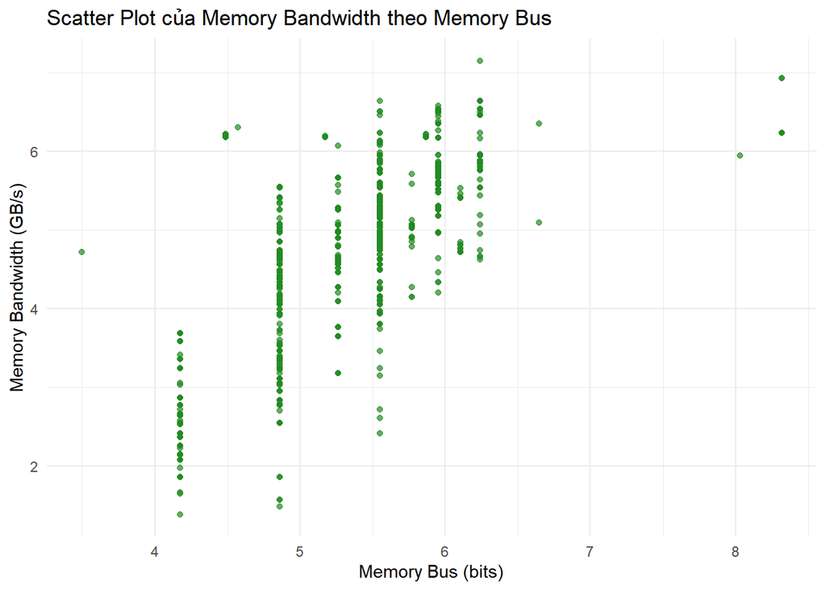

```r
# Vẽ scatter plot cho Memory_Bandwidth theo Memory_Bus
ggplot(main_GPU_data, aes(x = Memory_Bus, y = Memory_Bandwidth)) +
  geom_point(color = "forestgreen", alpha = 0.7) +  # Thay đổi màu sắc và độ trong suốt của điểm
  labs(title = "Scatter Plot của Memory Bandwidth theo Memory Bus",
       x = "Memory Bus (bits)",
       y = "Memory Bandwidth (GB/s)") +
  theme_minimal()
```

Dựa vào đồ thị phân tán trên, ta thấy rằng khi Memory Bus (bits) tăng lên, Memory Bandwidth (GB/s) cũng có xu hướng tăng. Thể hiện giữa biến Memory Bus và Memory Bandwidth có mối quan hệ tuyến tính dương. Ngụ ý rằng dung lượng bus bộ nhớ lớn hơn thường đi kèm với băng thông bộ nhớ cao hơn. Tuy nhiên, sự phân tán dữ liệu khá lớn, đặc biệt ở các mức Memory Bus thấp (từ 4 đến 6 bits), gợi ý rằng có thể có những yếu tố khác ngoài Memory Bus ảnh hưởng đến băng thông bộ nhớ, chẳng hạn như kiến trúc bộ nhớ hoặc các thông số phần cứng khác.

Việc chuẩn hóa biến Y (Memory Bandwidth) giúp dữ liệu trở nên đồng nhất hơn, giảm bớt ảnh hưởng của các giá trị ngoại lệ và làm rõ ràng hơn mối quan hệ giữa Memory Bus và băng thông bộ nhớ. Chuẩn hóa này không chỉ tạo điều kiện thuận lợi cho việc phân tích mà còn giúp dễ dàng nhận diện xu hướng chung hơn. Nhờ đó, các kết quả phân tích sẽ chính xác và có độ tin cậy cao hơn trong việc đánh giá mối liên hệ giữa hai biến.

4. Scatter plot cho biến Memory_Bandwidth theo biến Memory:

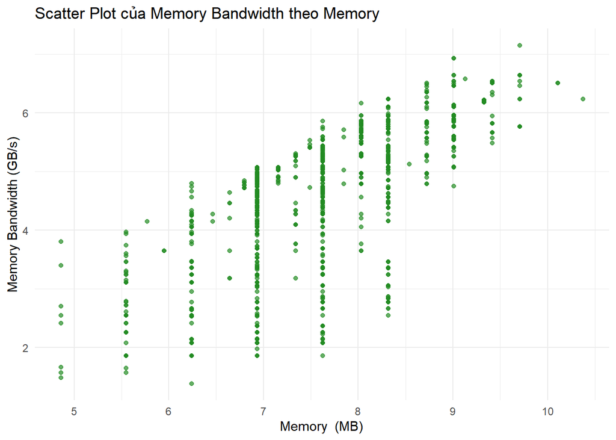

```r
# Vẽ scatter plot cho Memory_Bandwidth theo Memory
ggplot(main_GPU_data, aes(x = Memory, y = Memory_Bandwidth)) +
  geom_point(color = "forestgreen", alpha = 0.7) +  # Thay đổi màu sắc và độ trong suốt của điểm
  labs(title = "Scatter Plot của Memory Bandwidth theo Memory ",
       x = "Memory  (MB)",
       y = "Memory Bandwidth (GB/s)") +
  theme_minimal()
```

Dựa vào đồ thị phân tán, ta có thể rút ra một số nhận xét rằng mối quan hệ giữa “Memory Bandwidth” (Băng thông bộ nhớ) và “Memory” (Bộ nhớ) thể hiện xu hướng tăng dần, nghĩa là khi bộ nhớ tăng, băng thông bộ nhớ cũng có xu hướng tăng. Tuy nhiên, dữ liệu phân tán cho thấy sự phân bố không đồng nhất, có một số điểm tập trung dày đặc ở những mức bộ nhớ nhất định, đặc biệt là trong khoảng từ 7 MB đến 9 MB. Điều này có thể gợi ý rằng, trong một số dải bộ nhớ nhất định, băng thông có sự biến động lớn hơn.

Sau khi chuẩn hóa trục Y (băng thông bộ nhớ), dữ liệu có thể trở nên dễ dàng so sánh hơn giữa các mức bộ nhớ khác nhau. Việc chuẩn hóa giúp làm nổi bật sự khác biệt về hiệu suất và giúp xác định xu hướng chung một cách rõ ràng hơn. Điều này có thể có lợi trong việc đánh giá hiệu quả sử dụng bộ nhớ khi áp dụng vào các phân tích sâu hơn, đặc biệt là để nhận diện các điểm bất thường hoặc tìm ra các yếu tố tác động đến sự thay đổi của băng thông.

4. Vẽ đồ thị Hình Hộp (Box plot) cho biến Memory_Bandwidth theo các biến Phân Loại:  
   a. Đồ thị Boxplot cho biến Memory_Bandwidth theo biến Dedicated:

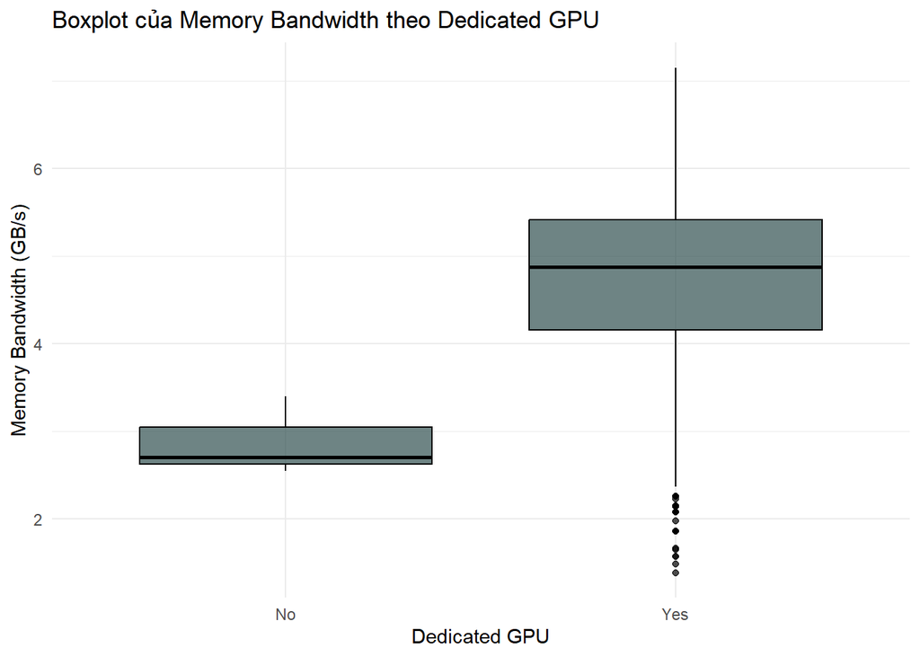

```r
# Vẽ boxplot cho Memory_Bandwidth theo Dedicated
ggplot(main_GPU_data, aes(x = Dedicated, y = Memory_Bandwidth)) +
  geom_boxplot(fill = "darkslategray", color = "black", alpha = 0.7) +  # Thay đổi màu sắc và độ trong suốt của hộp
  labs(title = "Boxplot của Memory Bandwidth theo Dedicated GPU",
       x = "Dedicated GPU",
       y = "Memory Bandwidth (GB/s)") +
  theme_minimal() +
  theme(axis.text.x = element_text(angle = 0, hjust = 0.5))  # Điều chỉnh vị trí nhãn trục x
```

Dựa vào đồ thị boxplot, có thể thấy rằng nhóm có GPU chuyên dụng (“Yes”) có băng thông bộ nhớ cao hơn đáng kể so với nhóm không có GPU chuyên dụng (“No”). Điều này được thể hiện qua giá trị trung vị và khoảng tứ phân vị của nhóm “Yes” lớn hơn. Bên cạnh đó, dải giá trị của nhóm “Yes” cũng rộng hơn, cho thấy sự phân bố dữ liệu không đồng nhất và sự đa dạng cao hơn về băng thông.

Ngoài ra, nhóm “Yes” có nhiều điểm ngoại lệ (outliers) nằm dưới đáy hộp, cho thấy một số trường hợp có băng thông thấp hơn mức trung bình. Trong khi đó, nhóm “No” có hộp dữ liệu hẹp hơn và ít điểm ngoại lệ, phản ánh sự đồng nhất cao hơn về băng thông bộ nhớ. Điều này cho thấy rằng mặc dù GPU chuyên dụng thường đem lại băng thông bộ nhớ cao hơn, nhưng đi kèm với sự biến động lớn hơn về hiệu suất.

2. Đồ thị Boxplot cho biến Memory_Bandwidth theo biến Shader:

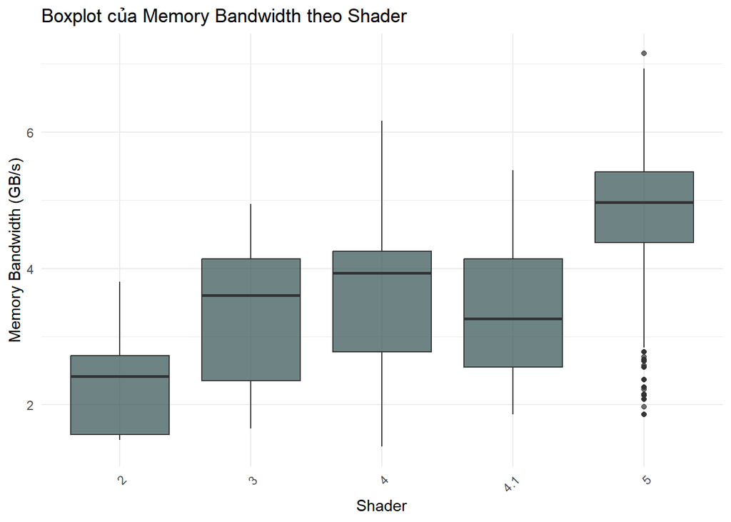

```r
# Vẽ boxplot cho Memory_Bandwidth theo Shader
ggplot(main_GPU_data, aes(x = Shader, y = Memory_Bandwidth)) +
  geom_boxplot(fill = "darkslategray", alpha = 0.7) +  # Thay đổi màu sắc và độ trong suốt
  labs(title = "Boxplot của Memory Bandwidth theo Shader",
       x = "Shader",
       y = "Memory Bandwidth (GB/s)") +
  theme_minimal() +
  theme(axis.text.x = element_text(angle = 45, hjust = 1))  # Xoay nhãn trục x
```

Nhìn chung, mỗi loại shader có liên quan đến một mức băng thông bộ nhớ khác nhau, cho thấy sự tương thích giữa loại shader và cấu hình phần cứng. Shader cao hơn yêu cầu phần cứng mạnh mẽ hơn với băng thông bộ nhớ lớn hơn, từ đó giúp xác định cấu hình tối ưu cho từng loại shader và tác vụ đặc thù.

3. Đồ thị Boxplot cho biến Memory_Bandwidth theo biến Manufacturer:

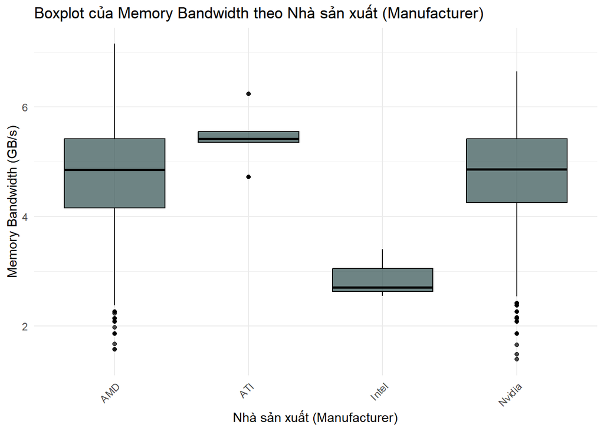

```r
 # Vẽ boxplot cho Memory_Bandwidth theo Manufacturer
ggplot(main_GPU_data, aes(x = Manufacturer, y = Memory_Bandwidth)) +
  geom_boxplot(fill = "darkslategray", color = "black", alpha = 0.7) +  # Thay đổi màu sắc và độ trong suốt của hộp
  labs(title = "Boxplot của Memory Bandwidth theo Nhà sản xuất (Manufacturer)",
       x = "Nhà sản xuất (Manufacturer)",
       y = "Memory Bandwidth (GB/s)") +
  theme_minimal() +
  theme(axis.text.x = element_text(angle = 45, hjust = 1))  # Xoay nhãn trục x để dễ đọc hơn
```

Tóm lại, mỗi nhà sản xuất có đặc điểm băng thông bộ nhớ khác nhau: ATI nổi bật với băng thông cao và ổn định; Intel thiên về băng thông thấp và đồng nhất; còn AMD và Nvidia có băng thông đa dạng, phù hợp với nhiều phân khúc từ trung bình đến cao.

# III. THÔNG KÊ SUY DIỄN

1. Bài toán 1 mẫu :
- Tìm khoảng ước lượng cho tỷ lệ | (trung bình) tổng thể:

Đề bài: Xây dựng khoảng tin cậy 95% (hai phía) cho Tốc độ băng thông bộ nhớ trung bình (biến Memory_Bandwidth) dựa trên bộ dữ liệu hiện có.

Bước 1: Kiểm tra điều kiện phân phối chuẩn của biến Memory_Bandwidth.

Cách 1: Sử dụng đồ thị để kiểm tra:  
Để xác định liệu biến Memory_Bandwidth có phân phối chuẩn hay không, ta sử dụng hai công cụ đồ thị: Histogram và Q-Q Plot

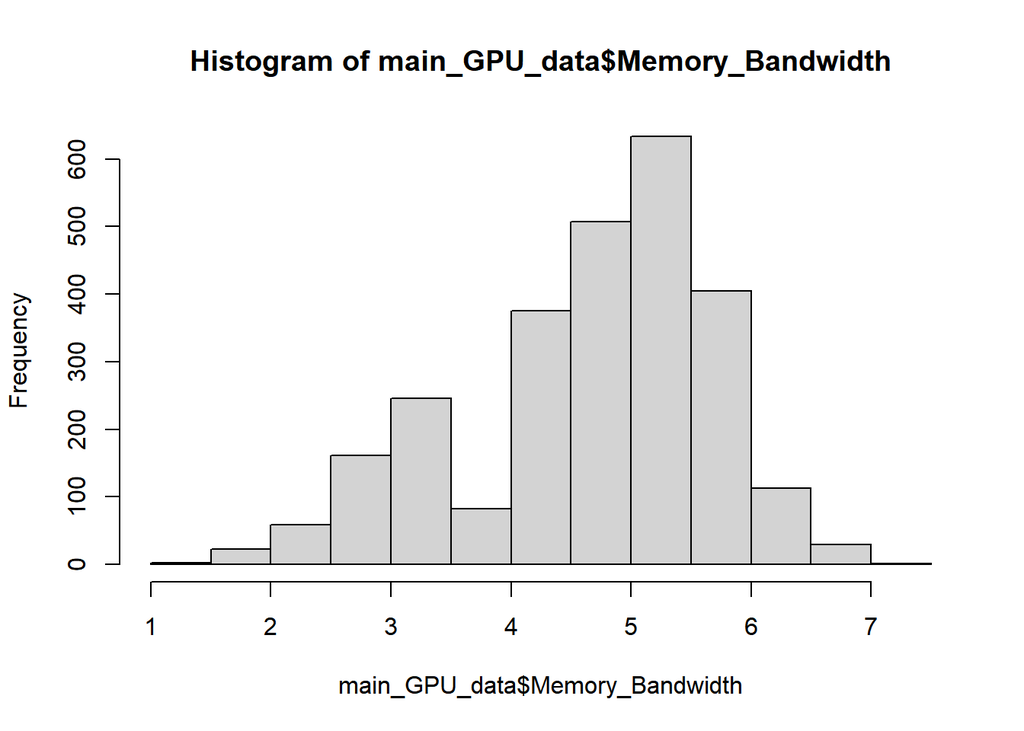

```r
hist(main_GPU_data$Memory_Bandwidth)
```

- Biểu đồ Histogram: Biểu đồ histogram cho thấy dữ liệu của biến Memory_Bandwidth có hình dáng gần với phân phối chuẩn, với phần lớn giá trị tập trung ở giữa biểu đồ. Tuy nhiên, biểu đồ này không hoàn toàn đối xứng, có xu hướng hơi lệch về phía các giá trị cao. Điều này cho thấy rằng phân phối của dữ liệu có phần tương tự phân phối chuẩn nhưng không hoàn toàn đạt yêu cầu về chuẩn.

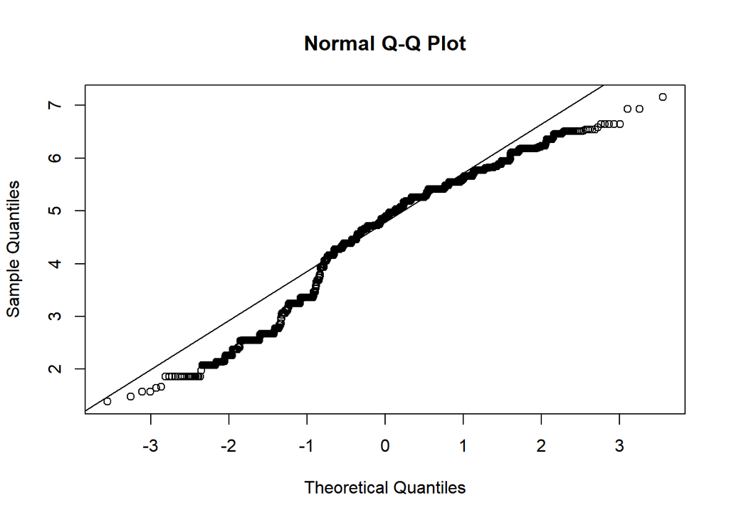

```r
qqnorm(main_GPU_data$Memory_Bandwidth)
qqline(main_GPU_data$Memory_Bandwidth)
```

- Biểu đồ Q-Q Plot: Khi quan sát biểu đồ Q-Q Plot, ta thấy rằng hầu hết các điểm dữ liệu nằm khá gần đường chéo, cho thấy xu hướng gần chuẩn của biến. Tuy nhiên, ở hai phần đuôi (các giá trị nhỏ nhất và lớn nhất), có một số điểm lệch khỏi đường chuẩn, cho thấy sự bất đồng nhất với phân phối chuẩn ở phần đuôi.

Dựa trên cả hai đồ thị, có thể kết luận rằng biến Memory_Bandwidth không tuân theo phân phối chuẩn. Mặc dù phần lớn giá trị của biến này có xu hướng gần chuẩn, nhưng sự lệch nhẹ và các ngoại lệ ở phần đuôi cho thấy phân phối không hoàn toàn phù hợp với phân phối chuẩn.

Lựa chọn phương pháp: Do dữ liệu không hoàn toàn tuân theo phân phối chuẩn, và cỡ mẫu lớn (n ≥ 30), do dó bài toán thuộc loại ước lượng trung bình với phân phối tùy ý.

Cách 2: Kiểm tra phân phối chuẩn của biến Memory_Bandwidth bằng phương pháp kiểm định giả thuyết.

Để xác định liệu Memory_Bandwidth có phân phối chuẩn hay không, ta thực hiện kiểm định với các giả thuyết sau:

- Giả thuyết H0: Biến Memory_Bandwidth có phân phối chuẩn.
- Giả thuyết H1: Biến Memory_Bandwidth không có phân phối chuẩn.

Sử dụng hàm (shapiro.test) để tính giá trị p-value. Dựa trên giá trị này, ta có thể đưa ra quyết định về giả thuyết H0 cần tìm.

- Nếu p-value ≥ 5% (mức ý nghĩa): Chưa có đủ bằng chứng để bác bỏ giả thuyết H0. Điều này có nghĩa là dữ liệu có thể được coi là có phân phối chuẩn.
- Nếu p-value < 5%: Bác bỏ giả thuyết H0, cho thấy dữ liệu không tuân theo phân phối chuẩn.

```r
shapiro.test(main_GPU_data$Memory_Bandwidth)
```

```
##
##  Shapiro-Wilk normality test
##
## data:  main_GPU_data$Memory_Bandwidth
## W = 0.9448, p-value < 2.2e-16
```

Với p-value rất nhỏ (nhỏ hơn mức ý nghĩa 5%), chúng ta có thể bác bỏ giả thuyết H0. Do đó, có thể kết luận rằng biến Memory_Bandwidth không tuân theo phân phối chuẩn.

- Kết luận: Bài toán thuộc dạng phân phối tùy ý và có cỡ mẫu lớn (n ≥ 30).

Bước 2: Tính các đặc trưng mẫu: Đầu tiên, ta cần tính các đặc trưng mẫu quan trọng, bao gồm:  
- n: kích thước mẫu (số quan sát).  
- X_tb: giá trị trung bình mẫu của Memory_Bandwidth.  
- s: độ lệch chuẩn mẫu.  
- z_critical: giá trị tới hạn z cho khoảng tin cậy 95% (hai phía) tại mức ý nghĩa 5%.

```r
#Tính các đặc trưng mẫu cửa biến
n <- length(main_GPU_data$Memory_Bandwidth)
X_tb <- mean(main_GPU_data$Memory_Bandwidth)
s <- sd(main_GPU_data$Memory_Bandwidth)

z_critical <- qnorm(p= .05/2, lower.tail = FALSE ) #Ngưỡng đối xứng

Esilon <-  qnorm(p= .05/2, lower.tail = FALSE ) * s/sqrt(n)

Left_CI <- X_tb - Esilon
Right_CT <- X_tb + Esilon

data.frame(n, X_tb, s, z_critical, Esilon, Left_CI, Right_CT)
```

```
##      n     X_tb        s z_critical     Esilon  Left_CI Right_CT
## 1 2637 4.667061 1.048176   1.959964 0.04000621 4.627055 4.707068
```

- Kết luận: Với khoảng tin cậy 95%, chúng ta có thể khẳng định rằng giá trị trung bình của biến Memory_Bandwidth nằm trong khoảng từ 4.627055 đến 4.707068.

# Xét Ngược Điều Kiện:

Giả sử biến Memory_Bandwidth có phân phối chuẩn nhưng ta chưa biết phương sai tổng thể.  
Trong trường hợp này, nếu coi rằng Memory_Bandwidth tuân theo phân phối chuẩn và chúng ta không biết phương sai tổng thể, ta sẽ sử dụng phân phối t thay vì phân phối z để xây dựng khoảng tin cậy 95% cho giá trị trung bình mẫu.

Các bước tính toán:

- n: Số lượng quan sát (kích thước mẫu).
- X_tb: Giá trị trung bình mẫu của Memory_Bandwidth.
- s: Độ lệch chuẩn mẫu.
- t_A: Giá trị tới hạn từ phân phối t với mức ý nghĩa 5% và bậc tự do df=𝑛−1.

```r
#Tính các đặc trưng mẫu cửa biến
n <- length(main_GPU_data$Memory_Bandwidth)
X_tb <- mean(main_GPU_data$Memory_Bandwidth)
s <- sd(main_GPU_data$Memory_Bandwidth)

t_A <- qt(p = .05/2, df=n-1, lower.tail=FALSE)

Esilon <-  qt(p = .05/2, df=n-1, lower.tail=FALSE) * s/sqrt(n)

Left_CI <- X_tb - Esilon
Right_CT <- X_tb + Esilon

data.frame(n, X_tb, s, z_critical, Esilon, Left_CI, Right_CT)
```

```
##      n     X_tb        s z_critical     Esilon  Left_CI Right_CT
## 1 2637 4.667061 1.048176   1.959964 0.04002458 4.627037 4.707086
```

- Kết luận: Với giả định biến Memory_Bandwidth tuân theo phân phối chuẩn, khoảng tin cậy 95% cho giá trị trung bình của biến Memory_Bandwidth nằm trong khoảng từ 4.627037 đến 4.707086.
  2. Bài toán 2 mẫu ( Kiểm định 2 mẫu cho 2 tỷ lệ hoặc 2 trung bình):
- Kiểm định so sánh Tốc độ Xử Lý Bộ Nhớ (Memory_Speed) Trung Bình giữa các nhà sản xuất ( Manufacture).

Đề bài: Với mức ý nghĩa 5%, hãy kiểm tra xem có sự Tốc độ Xử Lý Bộ Nhớ trung bình (Memory_Speed) của nhà sản xuất GPU “Nvidia” có cao hơn Tốc độ Xử Lý Bộ Nhớ trung bình (Memory_Speed) của nhà sản xuất GPU “AMD” hay không.

Ta chia dữ liệu biến Memory_Speed thành 2 nhóm như sau:  
- Nhóm 1(X1): Các GPU của nhà sản xuất Nvidia.  
- Nhóm 2(X2): Các GPU của nhà sản xuất AMD.

```r
Group_1_Data <- subset(main_GPU_data, Manufacturer == "Nvidia")
Group_2_Data <- subset(main_GPU_data, Manufacturer == "AMD")
```

Thiết lập giả thuyết kiểm định:  
- Giả thuyết H0: Tốc độ xử lý bộ nhớ (Memory_Speed) trung bình của GPU do “Nvidia” sản xuất không cao hơn (tức là thấp hơn hoặc bằng) tốc độ xử lý bộ nhớ trung bình của GPU do “AMD” sản xuất.  
- Giả thuyết H1: Tốc độ xử lý bộ nhớ (Memory_Speed) trung bình của GPU do “Nvidia” sản xuất cao hơn tốc độ xử lý bộ nhớ trung bình của GPU do “AMD” sản xuất.

- Kiểm tra kiện phân phối chuẩn của biến Memory_Speed thuộc Nhóm 1(Nvidia).  
  -Cách 1: Để xác định liệu biến Memory_Speed thuộc Nhóm 1(Nvidia) có phân phối chuẩn hay không, ta sử dụng công cụ đồ thị:Q-Q Plot

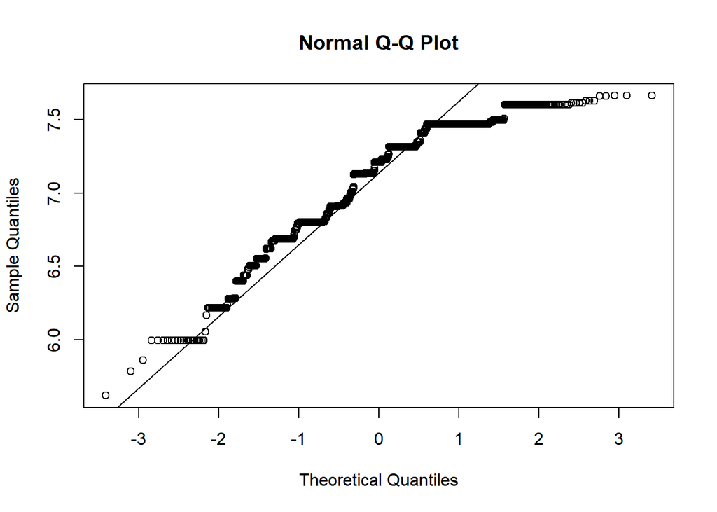

```r
qqnorm(Group_1_Data$Memory_Speed)
qqline(Group_1_Data$Memory_Speed)
```

* Đồ thị Q-Q Plot cho thấy các giá trị Memory_Speed của nhóm “Nvidia” có sự phân tán không hoàn toàn thẳng hàng với đường chéo lý thuyết của phân phối chuẩn. Các điểm dữ liệu ở hai phần đuôi (giá trị nhỏ nhất và lớn nhất) lệch xa khỏi đường thẳng, cho thấy sự bất đối xứng. Điều này cho thấy rằng phân phối của biến Memory_Speed trong nhóm “Nvidia” có xu hướng lệch, không tuân theo quy luật của phân phối chuẩn một cách chặt chẽ.

-Cách 2: Để xác định liệu biến Memory_Speed thuộc Nhóm 1(Nvidia) có phân phối chuẩn hay không, ta sử dụng phương pháp kiểm định giả thuyết.

Để xác định liệu Memory_Bandwidth có phân phối chuẩn hay không, ta thực hiện kiểm định với các giả thuyết sau:

- Giả thuyết H0: Biến Memory_Bandwidth có phân phối chuẩn.
- Giả thuyết H1: Biến Memory_Bandwidth không có phân phối chuẩn.

Sử dụng hàm (shapiro.test) để tính giá trị p-value. Dựa trên giá trị này, ta có thể đưa ra quyết định về giả thuyết H0 cần tìm.

- Nếu p-value ≥ 5% (mức ý nghĩa): Chưa có đủ bằng chứng để bác bỏ giả thuyết H0. Điều này có nghĩa là dữ liệu có thể được coi là có phân phối chuẩn.
- Nếu p-value < 5%: Bác bỏ giả thuyết H0, cho thấy dữ liệu không tuân theo phân phối chuẩn.

```r
shapiro.test(Group_1_Data$Memory_Speed)
```

```
##
##  Shapiro-Wilk normality test
##
## data:  Group_1_Data$Memory_Speed
## W = 0.91946, p-value < 2.2e-16
```

Kết quả của hàm kiểm định shpiro.test() cho p-value rất nhỏ (p-value < 2.2e-16), nghĩa là thấp hơn đáng kể so với ngưỡng ý nghĩa 5% (0.05).P-value nhỏ như vậy cho phép chúng ta bác bỏ giả thuyết H0, tức là giả thuyết cho rằng dữ liệu tuân theo phân phối chuẩn.

==> Kết luận tổng thể: Cả đồ thị Q-Q Plot và kết quả kiểm định Shapiro.test() đều nhất quán, cho thấy dữ liệu Memory_Speed trong nhóm “Nvidia” không tuân theo phân phối chuẩn.

- Kiểm tra kiện phân phối chuẩn của biến Memory_Speed thuộc Nhóm 2(AMD).

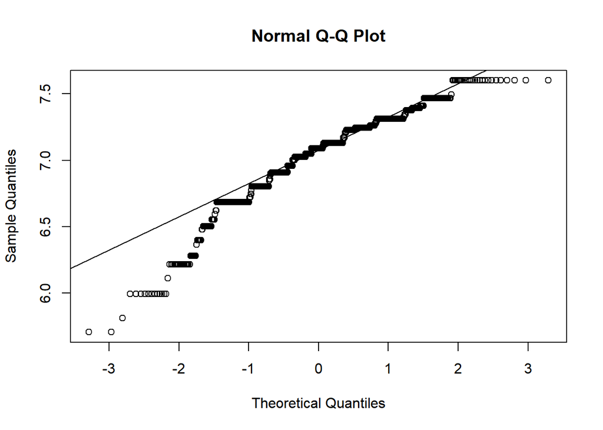

```r
qqnorm(Group_2_Data$Memory_Speed)
qqline(Group_2_Data$Memory_Speed)
```

Đồ thị Q-Q Plot của Memory_Speed cho nhóm “AMD” cho thấy nhiều điểm dữ liệu không nằm trên đường thẳng lý thuyết của phân phối chuẩn. Đặc biệt, các giá trị ở hai đầu (đuôi) có sự lệch đáng kể, thể hiện sự bất đối xứng trong dữ liệu và cho thấy dữ liệu có thể không tuân theo phân phối chuẩn.

```r
shapiro.test(Group_2_Data$Memory_Speed)
```

```
##
##  Shapiro-Wilk normality test
##
## data:  Group_2_Data$Memory_Speed
## W = 0.93776, p-value < 2.2e-16
```

-Kết quả của hàm kiểm định shpiro.test() với p-value < 2.2e-16 nhỏ hơn rất nhiều so với ngưỡng ý nghĩa 5% (0.05). Điều này dẫn đến việc bác bỏ giả thuyết H0, tức là giả thuyết cho rằng Memory_Speed của nhóm “AMD” tuân theo phân phối chuẩn.

- Kết luận tổng quát cho cả hai nhóm (Nvidia và AMD):

Cả hai nhóm dữ liệu Memory_Speed của Nvidia và AMD đều cho thấy không tuân theo phân phối chuẩn, do dó bài toán thuộc loại bại toán kiểm định với 2 mẫu độc lập; X1, X2 có phân phối bất kỳ và cỡ mẫu lớnlớn

Bước 2: Tính các đặc trưng mẫu:

- Từ dữ liệu, ta tính toán các đặc trưng mẫu cho mỗi nhóm như sau:

```r
#Tính các đặc trưng mẫu cửa biến Nhóm 1
n1 <- length(Group_1_Data$Memory_Speed)
X1_tb <- mean(Group_1_Data$Memory_Speed)
s1 <- sd(Group_1_Data$Memory_Speed)
#Tính các đặc trưng mẫu cửa biến Nhóm 2
n2 <- length(Group_2_Data$Memory_Speed)
X2_tb <- mean(Group_2_Data$Memory_Speed)
s2 <- sd(Group_2_Data$Memory_Speed)
# IN khung dữ liệu
data.frame(n1, X1_tb, s1, n2, X2_tb, s2)
```

```
##     n1    X1_tb        s1   n2    X2_tb        s2
## 1 1548 7.118857 0.3654309 1004 7.038201 0.3117913
```

- Tính giá trị kiểm định Z thực nghiệm (Z0):

```r
z0 <- (X1_tb - X2_tb)/sqrt(s1^2/n1 + s2^2/n2)
print(z0)
```

```
## [1] 5.960795
```

Tìm giá trị tới hạn: Đối với kiểm định một phía và mức ý nghĩa 𝛼= 0.05, giá trị tới hạn là:

```r
qnorm(p= .05, lower.tail = FALSE ) #Z(a) với mức ý nghĩ 5% ----- qnorm(p= .01, lower.tail = FALSE ) a = 1%
```

```
## [1] 1.644854
```

Miền bác bỏ: RR =(1.645,+∞)

# Xét Ngược Điều Kiện:

Giả sử tổng thể 𝑋1 và 𝑋2 là hai mẫu độc lập và có phân phối chuẩn. Khi đó, chúng ta sẽ thực hiện kiểm định phương sai hai mẫu để so sánh sự khác biệt về phương sai giữa hai nhóm.

- Đặt Giả Thuyết
- Giả thuyết 𝐻0: Phương sai của nhóm 1 bằng phương sai của nhóm 2, tức là 𝜎1^2 = σ2^2.
- Giả thuyết H1: Phương sai của nhóm 1 lớn hơn phương sai của nhóm 2, tức là 𝜎1^2 > σ2^2

Lưu ý: Dấu bất đẳng thức trong giả thuyết thay đổi tùy thuộc vào các giá trị mẫu. Trong trường hợp này, vì 𝑠1 >𝑠2 , chúng ta sẽ kiểm định xem phương sai của nhóm 1 có lớn hơn phương sai của nhóm 2 hay không.

Bước 1: Thực hiện kiểm định phương sai hai mẫu Ta sử dụng kiểm định F để so sánh phương sai của hai nhóm, với giả thuyết một phía (alternative = “greater”).

```r
var.test(Group_1_Data$Memory_Speed, Group_2_Data$Memory_Speed, alternative = "greater")
```

```
##
##  F test to compare two variances
##
## data:  Group_1_Data$Memory_Speed and Group_2_Data$Memory_Speed
## F = 1.3737, num df = 1547, denom df = 1003, p-value = 2.378e-08
## alternative hypothesis: true ratio of variances is greater than 1
## 95 percent confidence interval:
##  1.249317      Inf
## sample estimates:
## ratio of variances
##           1.373671
```

Bước 2: Tính giá trị kiểm định t thực nghiệm (t_0)

```r
t_0 <- (X1_tb - X2_tb)/sqrt(s1^2/n1 + s2^2/n2)
print(t_0)
```

```
## [1] 5.960795
```

- Bước 3: Xác định miền bác bỏ RR: Do phương sai giữa hai nhóm là khác nhau, ta cần tính toán bậc tự do hiệu quả 𝑉 cho kiểm định t-test tiếp theo

```r
v <- (((s1^2/n1)+(s2^2/n2))^2)/((((s1^2/n1)^2)/(n1 - 1)) + (((s2^2/n2)^2)/(n2 - 1)))
print(v)
```

```
## [1] 2367.799
```

```r
t_A <- qt(p = .05, df = v, lower.tail=FALSE)
print(t_A)
```

```
## [1] 1.645497
```

Miền bác bỏ: RR =(1.645,+∞).

Vì t_0 = 5.960795 nằm trong miền bác bỏ, ta đủ cơ sở để bác bỏ giả thuyết 𝐻0. Do đó, ta có thể chấp nhận giả thiết H1. Kết luận rằng, Tốc độ Xử Lý Bộ Nhớ trung bình của Nvidia cao hơn AMD.